# Exploratory Analysis and Predictive Modeling of COVID-19 Test Results in Israel

# Introduction

This notebook contains the exploratory analysis and predictive modeling of COVID-19 test results and sickness symptom. It uses the COVID-19 Symptoms dataset sourced from the Israeli Ministry of Health.

Since we will be predicting the outcome of a medical test, we are facing a **classification** task. That means the outcome we predict is binary (positive/negative).

## Predictive Questions

The first hypothesis will aim to explore the possibility of predicting COVID test results just from five simple symptoms. It is, however, unlikely this hypothesis will not be rejected as COVID symptoms are similar to those of common cold.

$$H_1: Can\: simple\: symptoms\: be\: used\: to\: predict\: positive\:
COVID\: test\: results\: with\: sensitivity\: ≥\: 90\: \%?$$

However, it is possible that including additional explanatory variables will help the accuracy of the model, therefore the second hypothesis:

$$H_2: Do\: additional \:independent \:variables \:in \:the \:dataset
\:increase \:baseline \:sensitivity?$$

It is also possible that there is some seasonal variation, for example, there might be more positives on Mondays due to less testing over the weekend or meeting more people on Fridays.

$$H_3: Are\: there\: any\: seasonal\: effects\:?$$

## Exploratory Questions

Exploratory questions are focused around predictive questions. They are divided into three categories, depending on the examined variables: symptoms, seasonal patterns and demographics.

### Symptoms Analysis

The operational hypothesis is that some symptoms have a higher predictive power than others that are more common acorss diseases (for example, caused by immunity system activation such as fever), or that a specific combination or number of symptoms have an effect on being positively tested, therefore two exploratory questions:

$$Q_1: Which\: symptoms\: are\: most\: common\: among\: positively\:
tested\: and\: do\: they\: differ\: from\: negatively\: tested?$$

$$Q_2: Does\: having\: at\: least\: two\: or\: three\: symptoms\: affect\:
symptoms\: occurence\: between\: positive\: and\: negative\: tests?$$

### Seasonal Patterns

Secondly, it is possible that a seasonal pattern affects positivity rate or the absolute number of positives. However, as we will see, the dataset can only be aggreagted to days of week. Therefore, the questions explore the weekly seasonal pattern.

$$Q_3: Do\: symptoms\: in\: positive\: results\: change\: over\: days\:
of\: the\: week?$$

$$Q_4: Do\: infection\: rates\: change\: over\: days\: of\: the\: week?$$

### Demographic Patterns

Lastly, demographic patterns are examined. The hypotheses are that older people can have a higher number and more severe symptoms or that the positivity differs between genders. In addition, the reason for being tested (travelling, contact with infected) will surely affect the test result. The questions are thus:

$$Q_5: Is\: positivity\: rate\: different\: between\: age \:groups \:and
\:genders?$$

$$Q_6: Does\: percentage\: of\: positive\: tests\: differ\: based\: on\:
reason\: to\: test\:?$$

For quick navigation, you can use contents:

1. Data Processing
2. Exploratory Analysis
3. Predictive Model
4. Conclusions
5. References

# Data Processing

Before doing any processing, let’s start with having a glimpse of the raw data, see unique values in categorical columns and xray for any problematic variables and distributions.

```r
glimpse(covid_data)
```

```
## Rows: 278,848
## Columns: 10
## $ test_date           <date> 2020-04-30, 2020-04-30, 2020-04-30, 2020-04-30, 2…
## $ cough               <dbl> 0, 1, 0, 1, 1, 1, 1, 0, 0, 0, 1, 0, 0, 0, 0, 1, 0,…
## $ fever               <dbl> 0, 0, 1, 0, 0, 0, 1, 0, 0, 0, 1, 0, 0, 0, 0, 0, 0,…
## $ sore_throat         <dbl> 0, 0, 0, 0, 0, 0, 0, 0, 0, 0, 0, 0, 0, 0, 0, 0, 0,…
## $ shortness_of_breath <dbl> 0, 0, 0, 0, 0, 0, 0, 0, 0, 0, 0, 0, 0, 0, 0, 0, 0,…
## $ head_ache           <dbl> 0, 0, 0, 0, 0, 0, 0, 0, 0, 0, 0, 0, 0, 0, 0, 0, 0,…
## $ corona_result       <chr> "negative", "negative", "negative", "negative", "n…
## $ age_60_and_above    <chr> "None", "None", "None", "None", "None", "None", "N…
## $ gender              <chr> "female", "female", "male", "female", "male", "fem…
## $ test_indication     <chr> "Other", "Other", "Other", "Other", "Other", "Othe…
```

```r
# Show unique values for each column, encode test date as categorical variables
unique_values <- covid_data %>%
                  mutate(day_of_week = weekdays(test_date), # encode days
                  month_of_year = month(test_date, label = TRUE), # encode months
                  year = year(test_date)) %>%
                  dplyr::select(-c(test_date) )%>% # exlude date variable
                  sapply(unique)
unique_values
```

```
## $cough
## [1]  0  1 NA
##
## $fever
## [1]  0  1 NA
##
## $sore_throat
## [1]  0  1 NA
##
## $shortness_of_breath
## [1]  0  1 NA
##
## $head_ache
## [1]  0  1 NA
##
## $corona_result
## [1] "negative" "positive" "other"
##
## $age_60_and_above
## [1] "None" "Yes"  "No"
##
## $gender
## [1] "female" "male"   "None"
##
## $test_indication
## [1] "Other"                  "Abroad"                 "Contact with confirmed"
##
## $day_of_week
## [1] "Thursday"  "Wednesday" "Tuesday"   "Monday"    "Sunday"    "Saturday"
## [7] "Friday"
##
## $month_of_year
## [1] Apr Mar
## 12 Levels: Jan < Feb < Mar < Apr < May < Jun < Jul < Aug < Sep < ... < Dec
##
## $year
## [1] 2020
```

We can see that the dataset contains 10 variables:

1. `test_date` : date when the test was conducted, tests were done only in April and March 2020, so the only date-related variable we can extract is the day of the week
2. `cough`, `fever`, `sore_throat`, `shortness_of_breath`, `head_ache` : binary variables (1/0) indicating whether the tested patient experienced these symptoms
3. `corona_result` : **target predictor** variable indicating the test result outcome, “Other” likely meaning invalid test result
4. `age_60_and_above`: variable for age being >=60
5. `gender`: variable indicating gender
6. `test_indication`: categorical variable indicating whether the tested patient had contact with infected or traveled abroad or other reason for testing.

Because we are seeing mostly categorical variables, a more useful way of analysing problematic variables is to plot distributions of our variables.

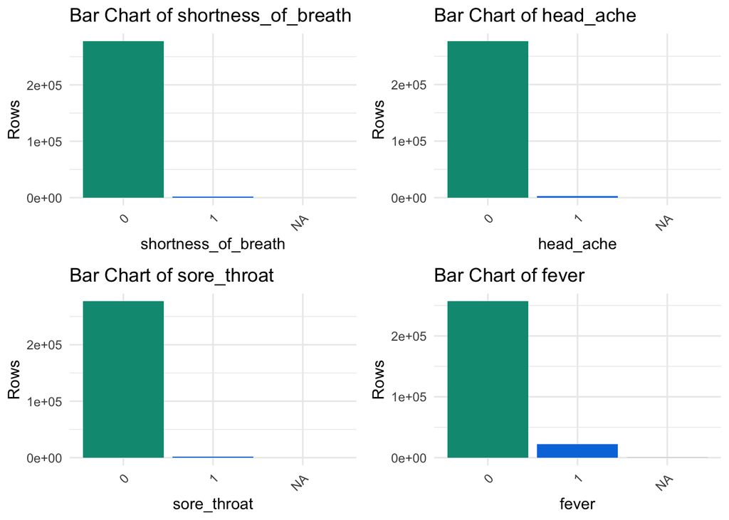

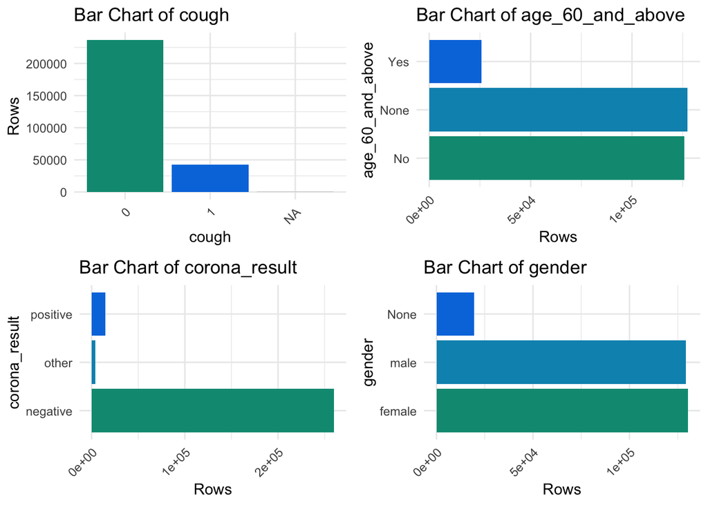

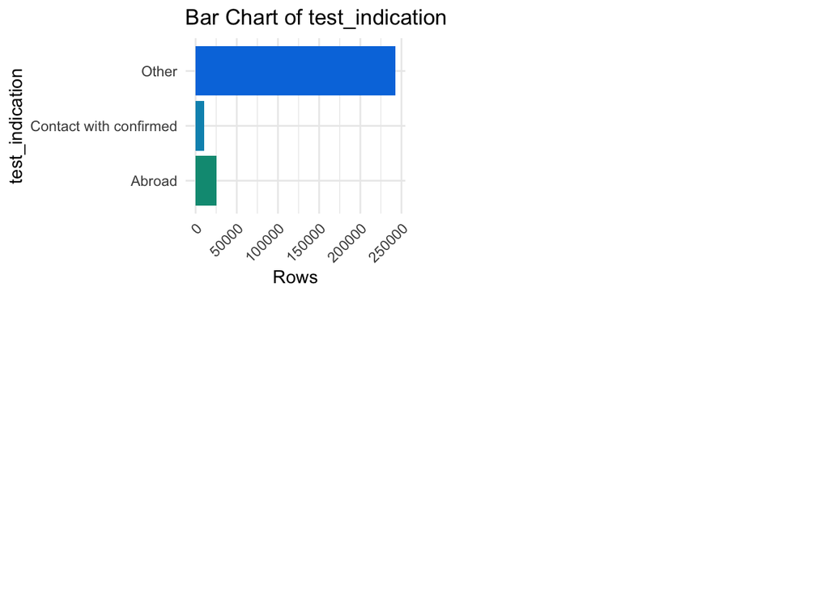

```
## [1] "Ignoring variable test_date: Unsupported type for visualization."
```

| Variable | p_1 | p_10 | p_25 | p_50 | p_75 | p_90 | p_99 |
| --- | --- | --- | --- | --- | --- | --- | --- |
| shortness_of_breath | 0 | 0 | 0 | 0 | 0 | 0 | 0 |
| sore_throat | 0 | 0 | 0 | 0 | 0 | 0 | 0 |
| head_ache | 0 | 0 | 0 | 0 | 0 | 0 | 0 |
| fever | 0 | 0 | 0 | 0 | 0 | 0 | 1 |
| cough | 0 | 0 | 0 | 0 | 0 | 1 | 1 |

#### Observations

There are several data processing steps that will be followed based on the initial data scanning:

```r
# Data Processing
# Create new column for day of the week
covid_data_dates <- covid_data %>%
    mutate(day_of_week = weekdays(test_date))

# Filter missing and inappropriate values for selected columns
# Define columns to check
columns_to_check <- c("cough", "fever", "sore_throat", "shortness_of_breath", "head_ache", "corona_result", "gender")

# Remove rows with missing, NA, or 'Other / None' values in specified columns
covid_filtered <- covid_data_dates %>%
  # Remove rows with NA values in the specified columns
  filter(if_all(all_of(columns_to_check), ~ !is.na(.))) %>%
  # Remove rows containing "None" or "Other" in the specified columns
  filter(if_all(all_of(columns_to_check), ~ !(. %in% c("None", "Other", "other"))))

# Create a new variable that is the horizontal sum of the symptom columns
symptom_columns <- c("cough", "fever", "sore_throat", "shortness_of_breath", "head_ache")

covid_filtered <- covid_filtered %>%
  mutate(symptom_count = rowSums(select(., all_of(symptom_columns)), na.rm = TRUE))

# Create factor variables for categorical columns
categorical_columns <- c("cough", "fever", "sore_throat", "shortness_of_breath", "head_ache", "corona_result", "gender", "test_indication", "age_60_and_above")

# Change binary columns to boolean
binary_cols <- c('cough', 'fever', 'sore_throat','shortness_of_breath', 'head_ache')

covid_filtered <- covid_filtered %>%
  mutate(across(all_of(binary_cols), ~ ifelse(. == 1, "Yes", "No")))

# Encode as factors
covid_filtered[categorical_columns] <- lapply(covid_filtered[categorical_columns], as.factor)

# Encode days of week as ordered factor levels
covid_filtered <- covid_filtered %>%
  mutate(
    day_of_week = factor(day_of_week, levels = c("Monday", "Tuesday", "Wednesday", "Thursday", "Friday", "Saturday", "Sunday"))
  )

# Drop date column
covid_filtered <- dplyr::select(covid_filtered, -c(test_date))
```

# Exploratory Analysis

We already had a glimpse of our data and we have some idea on how the dataset structure looks like and which variables are of our interest. Before proceeding with answering our exploratory questions, let us examine descriptive statistics within the sample.

## Descriptive statistics

```
##  cough        fever        sore_throat  shortness_of_breath head_ache
##  No :216616   No :235814   No :254172   No :254590          No :253565
##  Yes: 39052   Yes: 19854   Yes:  1496   Yes:  1078          Yes:  2103
##
##
##
##
##
##   corona_result    age_60_and_above    gender
##  negative:242136   No  :112593      female:128413
##  positive: 13532   None:119374      male  :127255
##                    Yes : 23701
##
##
##
##
##                test_indication      day_of_week    symptom_count
##  Abroad                : 23309   Monday   :39749   Min.   :0.0000
##  Contact with confirmed:  9593   Tuesday  :39224   1st Qu.:0.0000
##  Other                 :222766   Wednesday:37863   Median :0.0000
##                                  Thursday :42842   Mean   :0.2487
##                                  Friday   :33033   3rd Qu.:0.0000
##                                  Saturday :25662   Max.   :5.0000
##                                  Sunday   :37295
```

It is also important to know the share of positive test out of all tests done. Firstly, our prediction algorithm will focus primarily on positive results and having too few observations in relation to negative results will reduce performance for positive results. A very small percentage can also cause too few positive results in the test sample.

```r
infection_rate <- sum(covid_filtered$corona_result == "positive") / length(covid_filtered$corona_result) * 100

print(paste("The positivity rate for this sample is:", round(infection_rate, 2), "%."))
```

```
## [1] "The positivity rate for this sample is: 5.29 %."
```

#### Observations

The summary statistics and the positivity rate show a few insights:

- The symptoms and total number of symptoms are heavily skewed towards no symptoms
- Negative results are also dominant
- Together with positivity of 5.29% this can pose a significant issue for predicting positive results. Having too many negatives and no symptoms will not provide enough variance and bias the model towards negatives
- Gender variable is balanced
- Other demographic variables are also skewed but can provide value for the model

### Q1: Which symptoms are most common among positively tested individuals, and do they differ from negatively tested individuals?

The first question we ask, given our main predictive question, is whether and which symptoms are occurring between positively and negatively tested. While it might seem obvious, perhaps one of the symptoms is occurring as likely with negatively tested as with positively, because it is a symptom of cold and people wrongly assumed they had COVID and therefore would not have a predictive power on the COVID test result.

To answer the question, we plot summary bar charts of to see how frequently a given symptom occurs between positive and negative COVID test results.

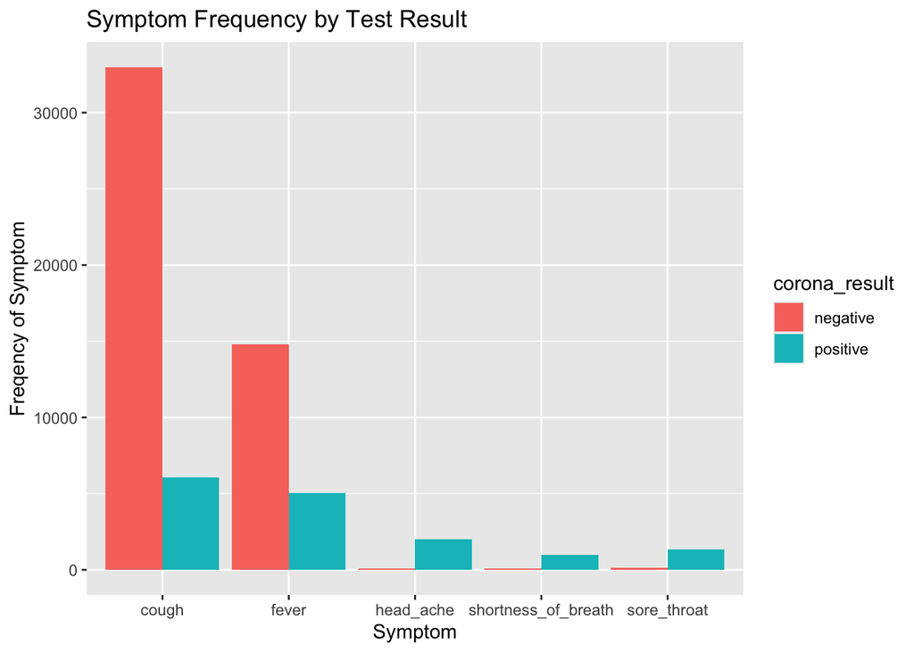

#### Observations

We can immediately see that cough and fever are such generic sickness symptoms, they can actually hinder our predictive performance if used alone. However, this opens up a the second question: while the symptoms alone can be misleading, what happens if they occur together?

### Q2: Does having at least two or three symptoms affect symptom occurrence between positive and negative tests?

For this, we feature engineered variable called count of symptoms that indicates how many symptoms does the tested person have and we will plot the same chart for people with at least two and three symptoms.

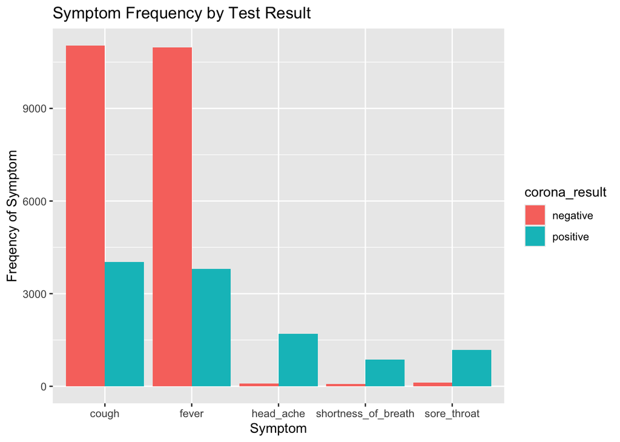

Now let us do the same for at least 3 symptoms.

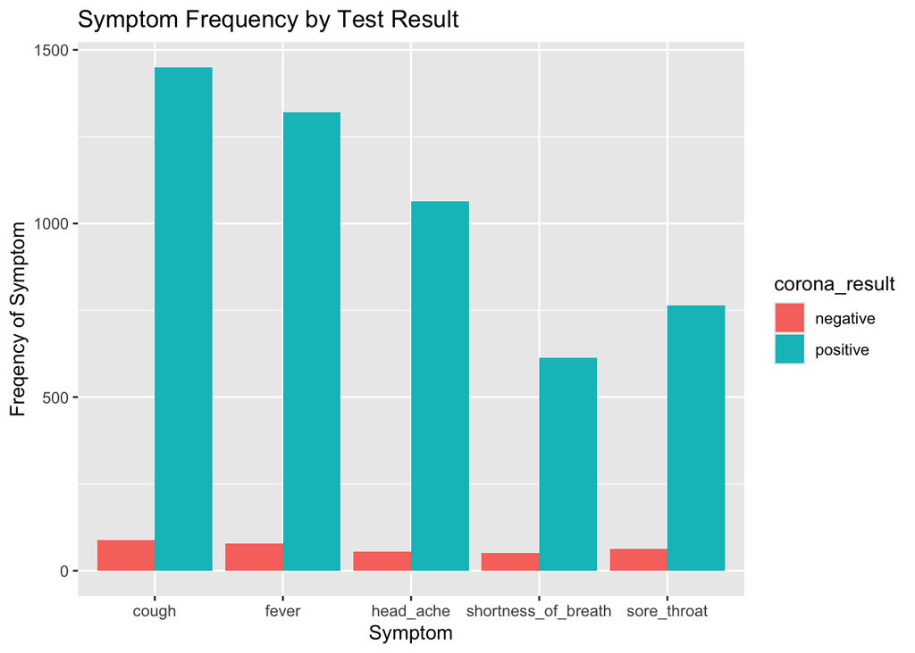

#### Observations

This is clearly showing that the number of symptoms is very important! Therefore, our engineered variable `symptoms_count` will certainly be useful for the predictive task. It is an indication that positive test results will be better predicted when there is coexistence of symptoms. As an additional question, we can ask, what is the number of positive results per each count of symptoms? This chart will show it for us:

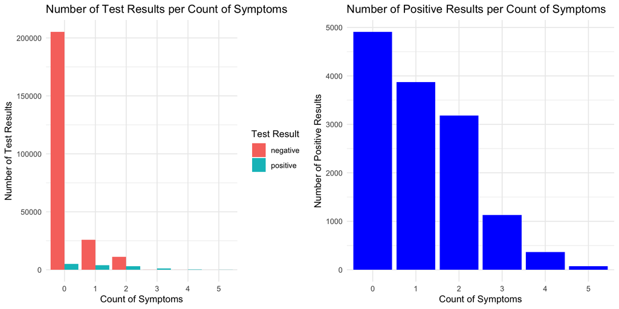

#### Observations

While we see that count of symptoms is very important, it will not have a large effect on people who have 2 or less symptoms and together they form a majority of positive cases. We would probably need to count of other variables to be strong predictors of a positive test or accept there is no way to predict it in these categories. Another important observation is that a lot of positively-tested individuals have no symptoms! This will make it difficult to predict the test result only based on symptoms.

### Q3: Do symptoms in positive results change over the days of the week?

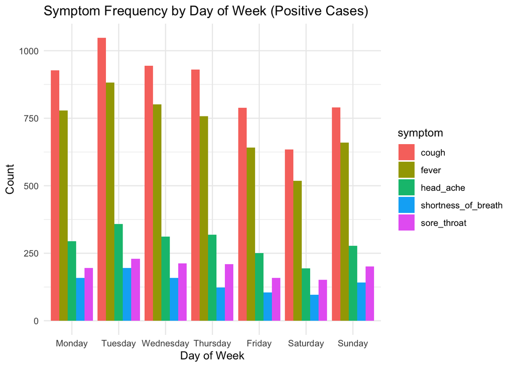

#### Observations

There is a clear weekdays pattern, in particular, we can see that symptoms frequency decreases on Fridays and Saturdays, likely caused by higher number of tests being conducted at the beginning of the week while doing less tests at the end. The ratio of symptoms seems to be similar across all weekdays.

### Q4: Do infection rates change over the days of the week?

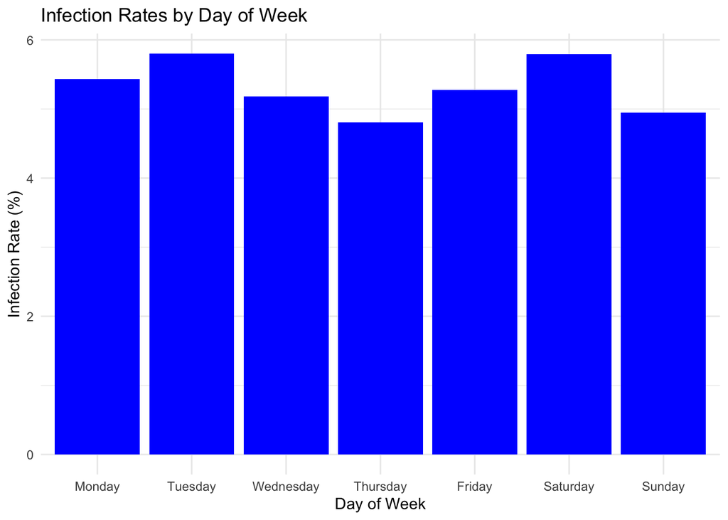

#### Observations

The figure of positivity rate across days of week is showing only slight pattern that is consistent with the previous hypothesis - positiviy is higher at the beginning of the week, likely caused by a higher socialisation over the weekend. However, this would not explain higher rate on Saturdays, which could be caused by some people being sick but unable to be tested during the week. People being more sick and having a higher priority could explain this but we cannot infer this observation.

### Q5: Is the positivity rate different between age groups and genders?

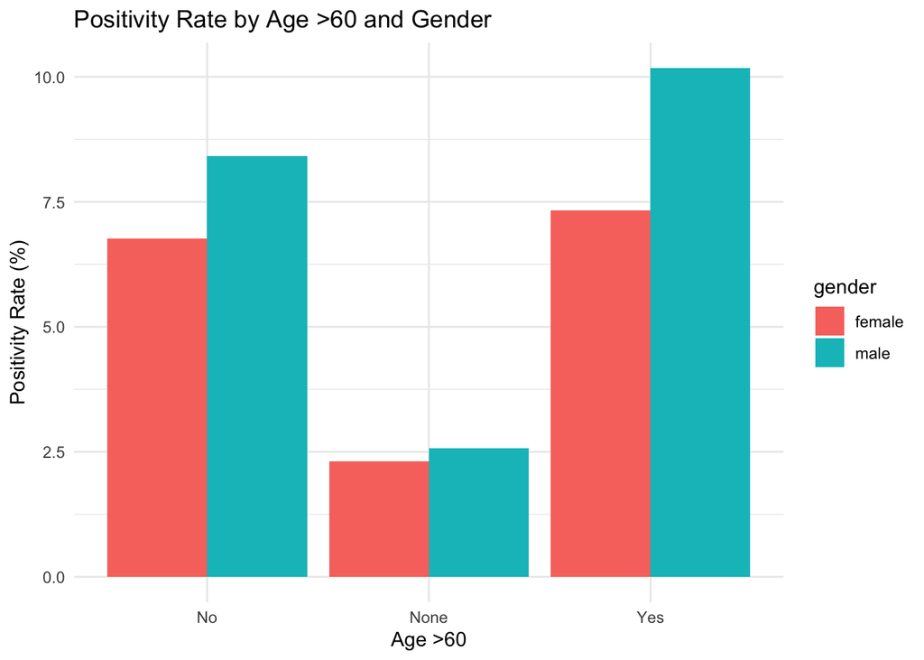

### Q6: Does the percentage of positive tests differ based on the reason for the test?

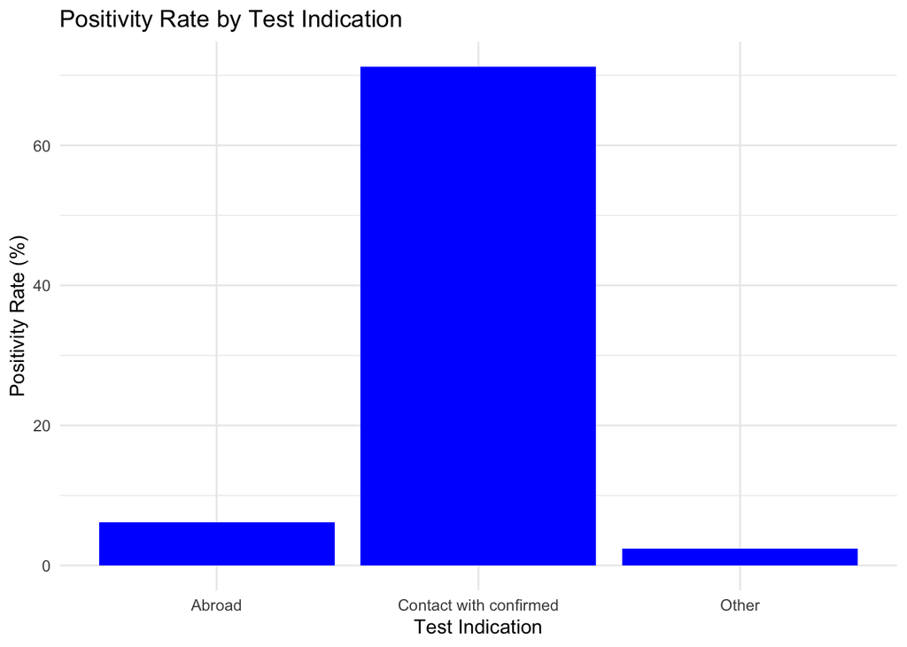

#### Observations

As expected, the positivity rate for those who had contact with confirmed COVID-infected, will likely also test positive. The rate is tremendously high, above 70%. Travelling abroad gives marginal advantage over the rest of the reasons for testing.

## Summary

There are a few points that can be carried into the predictive analysis:

- Low number of symptoms and generic symptoms will likely not have strong predictive power.
- Overall positivity is quite low which can bias the model, so a split containing a specific percentage of positively-tested will likely improve model performance.
- Having more symptoms can likely be a strong predictor for positive test result. Unfortunately, the majority of positively-tested have less than two or no symptoms at all.
- There could be some seasonality effects of the weekdays, but likely not so significant.
- Age, gender and the reason for testing will likely lead to better model performance

# Predictive Model

1. **Logistic regression (baseline)**: Chosen for its simplicity and interpretability as a baseline model.
2. **Random forest classifier**: Selected for its ability to handle high-dimensional data and capture non-linear relationships.
3. **Boosting algorithm**: Utilised for its robustness in improving model accuracy by combining weak learners.
4. **Neural Network**: Employed for its capacity to model complex patterns and interactions within the data.

The following is the general approach in this part:

1. Prepare data for the models
2. Train the models
3. Evaluate training and testing errors
4. Compare models with f1 score
5. Improve performance of the best model with:
- cross validation
- adding age variable
- hyper-parameter tuning
- using specific-share sample

## Preparing data

Because the share of positive tests in the sample is quite low, we need to ensure that both training and testing splits have the same distribution of positive / negative tests and we need to ensure that there is enough positive tests in relation to negative tests. Therefore we will create two datasets - stratified and a random sample merge (60% negatives and 40% positives) from both categories. Regular data will be used to select two best methods and a sample with specific share of positives will be used to fine tune the best model. We will use all available variables except `age_60_and_above`, because it contains many ‘None’ values and only an additional best performing model will utilise this dataset.

```r
# Make a copy of the dataset, age will be removed later
covid_filtered_2 <- covid_filtered

# Build a dataset with corona test result stratification
set.seed(123)
train_n <- createDataPartition(covid_filtered_2$corona_result, p = 0.7, list = FALSE) # createDataPartition has built in stratification
covid_train <- covid_filtered_2[train_n, ]
covid_test <- covid_filtered_2[-train_n, ]

# Remove age
covid_train_2 <- dplyr::select(covid_train, -c(age_60_and_above))
covid_test_2 <- dplyr::select(covid_test, -c(age_60_and_above))

# Build a dataset with a specific share of positive / negative results
# Get number of positive
positive_count <- covid_filtered_2 %>%
  filter(corona_result == "positive") %>%
  nrow()

# Create dataset of positives
positives <- covid_filtered_2 %>%
  filter(corona_result == "positive")

# Filter negatives
negatives <- covid_filtered_2 %>%
  filter(corona_result == "negative")

# Create index of random negatives based on 60 % share of negatives in final sample
share_negatives <- (positive_count / 0.4 - positive_count) / (positive_count + nrow(negatives))
index_negatives <- sample(1:nrow(negatives), round(nrow(negatives) * share_negatives))

# Subset negatives
negatives <- negatives[index_negatives,]

# Merge datasets and create train / test splits
merged <- rbind(positives, negatives)
covid_train_6_4_n <- initial_split(merged, prop = 0.7, strata = "corona_result")
covid_train_6_4 <- training(covid_train_6_4_n)
covid_test_6_4 <- testing(covid_train_6_4_n)
```

```r
# We can check stratification and specific stratification sampling
table(covid_train$corona_result) %>% prop.table()
```

```
##
##   negative   positive
## 0.94706905 0.05293095
```

```r
table(covid_test$corona_result) %>% prop.table()
```

```
##
##   negative   positive
## 0.94707884 0.05292116
```

```r
table(covid_train_6_4$corona_result) %>% prop.table()
```

```
##
##  negative  positive
## 0.5868807 0.4131193
```

```r
table(covid_test_6_4$corona_result) %>% prop.table()
```

```
##
##  negative  positive
## 0.5868946 0.4131054
```

The same data preparation process is repeated for data containing only symptoms to explore the first predictive question:

```r
# Select columns
covid_symptoms <- dplyr::select(covid_filtered, c(cough, fever, sore_throat, shortness_of_breath, head_ache, corona_result))

# Build a dataset with corona test result stratification
set.seed(123)
sympt_train_n <- createDataPartition(covid_symptoms$corona_result, p = 0.7, list = FALSE) # createDataPartition has built in stratification
sympt_train <- covid_symptoms[sympt_train_n, ]
sympt_test <- covid_symptoms[-sympt_train_n, ]

# Build a dataset with a specific share of positive / negative results
# Get number of positive
positive_count <- covid_symptoms %>%
  filter(corona_result == "positive") %>%
  nrow()

# Create dataset of positives
positives <- covid_symptoms %>%
  filter(corona_result == "positive")

# Filter negatives
negatives <- covid_symptoms %>%
  filter(corona_result == "negative")

# Create index of random negatives based on 60 % share of negatives in final sample
share_negatives <- (positive_count / 0.4 - positive_count) / (positive_count + nrow(negatives))
index_negatives <- sample(1:nrow(negatives), round(nrow(negatives) * share_negatives))

# Subset negatives
negatives <- negatives[index_negatives,]

# Merge datasets and create train / test splits
merged <- rbind(positives, negatives)
symptoms_train_6_4_n <- initial_split(merged, prop = 0.7, strata = "corona_result")
sympt_train_6_4 <- training(symptoms_train_6_4_n)
sympt_test_6_4 <- testing(symptoms_train_6_4_n)
```

```r
# We can check stratification and specific stratification sampling
table(sympt_train$corona_result) %>% prop.table()
```

```
##
##   negative   positive
## 0.94706905 0.05293095
```

```r
table(sympt_test$corona_result) %>% prop.table()
```

```
##
##   negative   positive
## 0.94707884 0.05292116
```

```r
table(sympt_train_6_4$corona_result) %>% prop.table()
```

```
##
##  negative  positive
## 0.5868807 0.4131193
```

```r
table(sympt_test_6_4$corona_result) %>% prop.table()
```

```
##
##  negative  positive
## 0.5868946 0.4131054
```

## Training and evaluating models

Now, we can train our models and evaluate their performance.

### Logistic Regression

Let us start with training the baseline model - logistic regression, with only symptoms being the predictors to answer our first predictive question. These models will not be fine tuned, as the exploratory analysis suggested having up to 2 symptoms is a pooor predictor of a positive result and majority of the sample has up to 2 symptoms.

#### Symptoms models

Firstly, a basic model on a normal stratified sample is fit, followed by a fit on the specific share sample.

```r
set.seed(123)
# Fit symptoms model and predict
log_sympt <- glm(corona_result ~ ., data = sympt_train, family = binomial)
sympt_num_pred <- predict(log_sympt, newdata = sympt_test, type = "response")
sympt_pred <-  as.factor(ifelse(sympt_num_pred > 0.5, "positive", "negative") )

# Fit the split symptoms model and predict
log_sympt_split <- glm(corona_result ~ ., data = sympt_train_6_4, family = binomial)
sympt_split_num_pred <- predict(log_sympt_split, newdata = sympt_test_6_4, type = "response")
sympt_split_pred <-  as.factor(ifelse(sympt_split_num_pred > 0.5, "positive", "negative") )

# Evaluate performance
conf_matrix_sympt <- confusionMatrix(sympt_pred, sympt_test$corona_result, positive="positive")
conf_matrix_sympt_split <- confusionMatrix(sympt_split_pred, sympt_test_6_4$corona_result, positive="positive")
```

Now, checking the results:

```r
conf_matrix_sympt
```

```
## Confusion Matrix and Statistics
##
##           Reference
## Prediction negative positive
##   negative    72575     3056
##   positive       65     1003
##
##                Accuracy : 0.9593
##                  95% CI : (0.9579, 0.9607)
##     No Information Rate : 0.9471
##     P-Value [Acc > NIR] : < 2.2e-16
##
##                   Kappa : 0.3775
##
##  Mcnemar's Test P-Value : < 2.2e-16
##
##             Sensitivity : 0.24711
##             Specificity : 0.99911
##          Pos Pred Value : 0.93914
##          Neg Pred Value : 0.95959
##              Prevalence : 0.05292
##          Detection Rate : 0.01308
##    Detection Prevalence : 0.01392
##       Balanced Accuracy : 0.62311
##
##        'Positive' Class : positive
##
```

```r
conf_matrix_sympt_split
```

```
## Confusion Matrix and Statistics
##
##           Reference
## Prediction negative positive
##   negative     5430     2111
##   positive      338     1949
##
##                Accuracy : 0.7508
##                  95% CI : (0.7421, 0.7593)
##     No Information Rate : 0.5869
##     P-Value [Acc > NIR] : < 2.2e-16
##
##                   Kappa : 0.4506
##
##  Mcnemar's Test P-Value : < 2.2e-16
##
##             Sensitivity : 0.4800
##             Specificity : 0.9414
##          Pos Pred Value : 0.8522
##          Neg Pred Value : 0.7201
##              Prevalence : 0.4131
##          Detection Rate : 0.1983
##    Detection Prevalence : 0.2327
##       Balanced Accuracy : 0.7107
##
##        'Positive' Class : positive
##
```

### All variables models (excluding age)

```r
set.seed(123)
# Fit the model and predict
log_model <- glm(corona_result ~ ., data = covid_train_2, family = binomial)
log_num_pred <- predict(log_model, newdata = covid_test_2, type = "response")
log_pred <-  as.factor(ifelse(log_num_pred > 0.5, "positive", "negative") )

# Evaluate performance
conf_matrix_log <- confusionMatrix(log_pred, covid_test_2$corona_result, positive="positive")

conf_matrix_log
```

```
## Confusion Matrix and Statistics
##
##           Reference
## Prediction negative positive
##   negative    71804     1587
##   positive      836     2472
##
##                Accuracy : 0.9684
##                  95% CI : (0.9671, 0.9696)
##     No Information Rate : 0.9471
##     P-Value [Acc > NIR] : < 2.2e-16
##
##                   Kappa : 0.6547
##
##  Mcnemar's Test P-Value : < 2.2e-16
##
##             Sensitivity : 0.60902
##             Specificity : 0.98849
##          Pos Pred Value : 0.74728
##          Neg Pred Value : 0.97838
##              Prevalence : 0.05292
##          Detection Rate : 0.03223
##    Detection Prevalence : 0.04313
##       Balanced Accuracy : 0.79875
##
##        'Positive' Class : positive
##
```

```r
summary(log_model)
```

```
##
## Call:
## glm(formula = corona_result ~ ., family = binomial, data = covid_train_2)
##
## Coefficients: (1 not defined because of singularities)
##                                       Estimate Std. Error z value Pr(>|z|)
## (Intercept)                           -4.00188    0.06032 -66.345  < 2e-16 ***
## coughYes                               0.10893    0.03791   2.873 0.004062 **
## feverYes                               1.53413    0.04057  37.817  < 2e-16 ***
## sore_throatYes                         4.05230    0.13109  30.912  < 2e-16 ***
## shortness_of_breathYes                 4.20787    0.14250  29.528  < 2e-16 ***
## head_acheYes                           4.91008    0.13476  36.436  < 2e-16 ***
## gendermale                             0.28078    0.02910   9.649  < 2e-16 ***
## test_indicationContact with confirmed  4.13950    0.05132  80.653  < 2e-16 ***
## test_indicationOther                  -0.18201    0.04802  -3.790 0.000151 ***
## day_of_weekTuesday                     0.03820    0.05036   0.758 0.448182
## day_of_weekWednesday                  -0.13194    0.05238  -2.519 0.011768 *
## day_of_weekThursday                   -0.08785    0.05084  -1.728 0.084004 .
## day_of_weekFriday                     -0.04488    0.05349  -0.839 0.401483
## day_of_weekSaturday                   -0.04190    0.05691  -0.736 0.461533
## day_of_weekSunday                     -0.16723    0.05345  -3.129 0.001756 **
## symptom_count                               NA         NA      NA       NA
## ---
## Signif. codes:  0 '***' 0.001 '**' 0.01 '*' 0.05 '.' 0.1 ' ' 1
##
## (Dispersion parameter for binomial family taken to be 1)
##
##     Null deviance: 74113  on 178968  degrees of freedom
## Residual deviance: 41247  on 178954  degrees of freedom
## AIC: 41277
##
## Number of Fisher Scoring iterations: 7
```

#### Random Forest Classifier

```r
set.seed(123)
# Fit model and predict
rf_model <- randomForest(corona_result ~ ., data = covid_train_2, importance = TRUE)
# Predict on test set
rf_pred <- predict(rf_model, newdata = covid_test_2)

# Evaluate performance
conf_matrix_rf <- confusionMatrix(rf_pred, covid_test_2$corona_result, positive="positive")

conf_matrix_rf
```

```
## Confusion Matrix and Statistics
##
##           Reference
## Prediction negative positive
##   negative    72132     1776
##   positive      508     2283
##
##                Accuracy : 0.9702
##                  95% CI : (0.969, 0.9714)
##     No Information Rate : 0.9471
##     P-Value [Acc > NIR] : < 2.2e-16
##
##                   Kappa : 0.6515
##
##  Mcnemar's Test P-Value : < 2.2e-16
##
##             Sensitivity : 0.56245
##             Specificity : 0.99301
##          Pos Pred Value : 0.81799
##          Neg Pred Value : 0.97597
##              Prevalence : 0.05292
##          Detection Rate : 0.02977
##    Detection Prevalence : 0.03639
##       Balanced Accuracy : 0.77773
##
##        'Positive' Class : positive
##
```

### XGBoost Classifier

```r
set.seed(123)

# Ensure that the predictor columns are numeric and exclude the target column
train_data <- covid_train_2[, -which(names(covid_train_2) == "corona_result")]
test_data <- covid_test_2[, -which(names(covid_test_2) == "corona_result")]

# Convert all predictors to numeric (if necessary)
train_data <- data.frame(lapply(train_data, as.numeric))
test_data <- data.frame(lapply(test_data, as.numeric))

# Convert the target variable to numeric (0 for negative, 1 for positive)
train_labels <- as.numeric(covid_train_2$corona_result) - 1  # 0 = negative, 1 = positive
test_labels <- as.numeric(covid_test_2$corona_result) - 1

# Convert the data to DMatrix format (required by xgboost)
dtrain <- xgb.DMatrix(data = as.matrix(train_data), label = train_labels)
dtest <- xgb.DMatrix(data = as.matrix(test_data), label = test_labels)

# Fit the XGBoost model
xgb_model <- xgboost(data = dtrain,
                     nrounds = 100,
                     objective = "binary:logistic",
                     eval_metric = "logloss",
                     max_depth = 6,
                     eta = 0.3,
                     verbose = 0)

# Make predictions on the test set
xgb_pred_prob <- predict(xgb_model, newdata = dtest)  # Predicted probabilities
xgb_pred <- ifelse(xgb_pred_prob > 0.5, "positive", "negative")  # Convert probabilities to class labels

# Evaluate performance
conf_matrix_xgb <- confusionMatrix(factor(xgb_pred, levels = c("negative", "positive")), factor(covid_test_2$corona_result, levels = c("negative", "positive")), positive = "positive")

conf_matrix_xgb
```

```
## Confusion Matrix and Statistics
##
##           Reference
## Prediction negative positive
##   negative    72063     1730
##   positive      577     2329
##
##                Accuracy : 0.9699
##                  95% CI : (0.9687, 0.9711)
##     No Information Rate : 0.9471
##     P-Value [Acc > NIR] : < 2.2e-16
##
##                   Kappa : 0.6535
##
##  Mcnemar's Test P-Value : < 2.2e-16
##
##             Sensitivity : 0.57379
##             Specificity : 0.99206
##          Pos Pred Value : 0.80145
##          Neg Pred Value : 0.97656
##              Prevalence : 0.05292
##          Detection Rate : 0.03037
##    Detection Prevalence : 0.03789
##       Balanced Accuracy : 0.78292
##
##        'Positive' Class : positive
##
```

### Neural net

Since there is only one numerical feature in the model, it is not needed to normalise the variables that are encoded as factor levels.

```r
set.seed(123)

# Prepare the data for training (excluding the target variable)
train_data <- covid_train_2[, -which(names(covid_train_2) == "corona_result")]
test_data <- covid_test_2[, -which(names(covid_test_2) == "corona_result")]

# Convert all predictors to numeric (if necessary)
train_data <- data.frame(lapply(train_data, as.numeric))
test_data <- data.frame(lapply(test_data, as.numeric))

# Convert the target variable to numeric (0 for negative, 1 for positive)
train_labels <- as.factor(covid_train_2$corona_result)  # Factor labels
test_labels <- as.factor(covid_test_2$corona_result)

# Fit a Neural Network model
nn_model <- nnet(corona_result ~ ., data = covid_train_2, size = 10, maxit = 500, linout = FALSE, trace=FALSE)

# Make predictions
nn_pred <- predict(nn_model, newdata = covid_test_2, type = "class")

# Evaluate performance
conf_matrix_nn <- confusionMatrix(as.factor(nn_pred), test_labels, positive="positive")

conf_matrix_nn
```

```
## Confusion Matrix and Statistics
##
##           Reference
## Prediction negative positive
##   negative    72071     1743
##   positive      569     2316
##
##                Accuracy : 0.9699
##                  95% CI : (0.9686, 0.9711)
##     No Information Rate : 0.9471
##     P-Value [Acc > NIR] : < 2.2e-16
##
##                   Kappa : 0.6517
##
##  Mcnemar's Test P-Value : < 2.2e-16
##
##             Sensitivity : 0.57058
##             Specificity : 0.99217
##          Pos Pred Value : 0.80277
##          Neg Pred Value : 0.97639
##              Prevalence : 0.05292
##          Detection Rate : 0.03020
##    Detection Prevalence : 0.03761
##       Balanced Accuracy : 0.78138
##
##        'Positive' Class : positive
##
```

## Compare performance of models

Now, an important step is to evaluate all models.

```r
# Extract metrics
metrics_log <- conf_matrix_log$byClass[c('Sensitivity', 'Specificity', 'Precision', 'F1')]
metrics_rf <- conf_matrix_rf$byClass[c('Sensitivity', 'Specificity', 'Precision', 'F1')]
metrics_xgb <- conf_matrix_xgb$byClass[c('Sensitivity', 'Specificity', 'Precision', 'F1')]
metrics_nn <- conf_matrix_nn$byClass[c('Sensitivity', 'Specificity', 'Precision', 'F1')]

# Combine into a data frame
metrics_df <- data.frame(
  Model = c('Logistic Regression', 'Random Forest', 'XGBoost', 'Neural Net'),
  Sensitivity = c(metrics_log['Sensitivity'], metrics_rf['Sensitivity'], metrics_xgb['Sensitivity'], metrics_nn['Sensitivity']),
  Specificity = c(metrics_log['Specificity'], metrics_rf['Specificity'], metrics_xgb['Specificity'], metrics_nn['Specificity']),
  Precision = c(metrics_log['Precision'], metrics_rf['Precision'], metrics_xgb['Precision'], metrics_nn['Precision']),
  F1 = c(metrics_log['F1'], metrics_rf['F1'], metrics_xgb['F1'], metrics_nn['F1'])
)

metrics_df
```

| Model | Sensitivity | Specificity | Precision | F1 |
| --- | --- | --- | --- | --- |
| Logistic Regression | 0.6090170 | 0.9884912 | 0.7472793 | 0.6711009 |
| Random Forest | 0.5624538 | 0.9930066 | 0.8179864 | 0.6665693 |
| XGBoost | 0.5737866 | 0.9920567 | 0.8014453 | 0.6687724 |
| Neural Net | 0.5705839 | 0.9921669 | 0.8027730 | 0.6670507 |

The table shows that logistic regression, the baseline model is the best-performing model in terms of sensitivity and F1 score. While its precision is lower, it is largely driven by scoring lower in specificity and we are not interested in a model that can predict uninteresting negative test results. The second best model is XGBoost. Therefore, logistic regression and XGBoost models will be tested against a specific strata sample and the better-performing out of the two will be fine-tuned.

## Improving performance of the best models

The first step is to train and compare the two models on the sample with 60% negative and 40% positive results. This sample also includes the age variable.

```r
set.seed(123)
# Logistic Regression
# Fit the model and predict
log_model_st <- glm(corona_result ~ ., data = covid_train_6_4, family = binomial)
log_num_pred_st <- predict(log_model_st, newdata = covid_test_6_4, type = "response")
log_pred_st <-  as.factor(ifelse(log_num_pred_st > 0.5, "positive", "negative") )

# Evaluate performance
conf_matrix_log_st <- confusionMatrix(log_pred_st, covid_test_6_4$corona_result, positive="positive")

# XGBoost
# Ensure that the predictor columns are numeric and exclude the target column
train_data <- covid_train_6_4[, -which(names(covid_train_6_4) == "corona_result")]
test_data <- covid_test_6_4[, -which(names(covid_test_6_4) == "corona_result")]

# Convert all predictors to numeric (if necessary)
train_data <- data.frame(lapply(train_data, as.numeric))
test_data <- data.frame(lapply(test_data, as.numeric))

# Convert the target variable to numeric (0 for negative, 1 for positive)
train_labels <- as.numeric(covid_train_6_4$corona_result) - 1  # 0 = negative, 1 = positive
test_labels <- as.numeric(covid_test_6_4$corona_result) - 1

# Convert the data to DMatrix format (required by xgboost)
dtrain <- xgb.DMatrix(data = as.matrix(train_data), label = train_labels)
dtest <- xgb.DMatrix(data = as.matrix(test_data), label = test_labels)

# Fit the XGBoost model
xgb_model_st <- xgboost(data = dtrain,
                     nrounds = 100,
                     objective = "binary:logistic",
                     eval_metric = "logloss",
                     max_depth = 6,
                     eta = 0.3,
                     verbose = 0)

# Make predictions on the test set
xgb_pred_prob_st <- predict(xgb_model_st, newdata = dtest)  # Predicted probabilities
xgb_pred_st <- ifelse(xgb_pred_prob_st > 0.5, "positive", "negative")  # Convert probabilities to class labels

# Evaluate performance
conf_matrix_xgb_st <- confusionMatrix(factor(xgb_pred_st, levels = c("negative", "positive")), factor(covid_test_6_4$corona_result, levels = c("negative", "positive")), positive = "positive")

# Compare performance
metrics_log_st <- conf_matrix_log_st$byClass[c('Sensitivity', 'Specificity', 'Precision', 'F1')]
metrics_xgb_st <- conf_matrix_xgb_st$byClass[c('Sensitivity', 'Specificity', 'Precision', 'F1')]

# Combine into a data frame
metrics_st <- data.frame(
  Model = c('Logistic Regression', 'XGBoost'),
  Sensitivity = c(metrics_log_st['Sensitivity'], metrics_xgb_st['Sensitivity']),
  Specificity = c(metrics_log_st['Specificity'], metrics_xgb_st['Specificity']),
  Precision = c(metrics_log_st['Precision'], metrics_xgb_st['Precision']),
  F1 = c(metrics_log_st['F1'], metrics_xgb_st['F1'])
)

metrics_st
```

| Model | Sensitivity | Specificity | Precision | F1 |
| --- | --- | --- | --- | --- |
| Logistic Regression | 0.7310345 | 0.9544036 | 0.9186011 | 0.8141544 |
| XGBoost | 0.7642857 | 0.9479889 | 0.9118425 | 0.8315691 |

The table is showing significant improvements, especially for the XGBoost model. Therefore, we will only continue with this model and tune model hyperparameters and use cross-validation to improve its performance.

```r
# Define the tuning grid
tune_grid <- expand.grid(
  nrounds = 100,            # Number of boosting rounds
  max_depth = c(4, 6, 8),           # Maximum depth of a tree
  eta = c(0.01, 0.1, 0.3),          # Learning rate
  gamma = c(0, 0.5),           # Minimum loss reduction
  colsample_bytree = c(0.75,1),     # Subsample ratio of columns
  min_child_weight = c(1,5,10),    # Minimum sum of instance weight (hessian) needed in a child
  subsample = c(0.75, 1)        # Subsample ratio of the training instance
)

# Define the control for cross-validation with custom summary function
control <- trainControl(
  method = "cv",                    # Cross-validation
  number = 5,                       # Number of folds
  verboseIter = FALSE,               # Verbose output
  allowParallel = TRUE,             # Allow parallel computation
)

# Start timer
start_time <- Sys.time()

# Train the XGBoost model with hyperparameter tuning
set.seed(123)
xgb_tune <- train(
  x = train_data,
  y = factor(train_labels, levels = c(0, 1), labels = c("negative", "positive")),
  method = "xgbTree",
  trControl = control,
  tuneGrid = tune_grid,
  metric = "Accuracy"
)

# Stop timer
end_time <- Sys.time()

# Calculate time taken
time_taken <- end_time - start_time
time_taken
```

```
## Time difference of 12.29396 mins
```

```r
xgb_tune$bestTune
```

|  | nrounds | max_depth | eta | gamma | colsample_bytree | min_child_weight | subsample |
| --- | --- | --- | --- | --- | --- | --- | --- |
| 77 | 100 | 4 | 0.1 | 0 | 0.75 | 10 | 0.75 |

```r
# Make predictions on the test set using the best tuned model
xgb_pred_prob_tuned <- predict(xgb_tune, newdata = test_data, type = "prob")[,2]  # Predicted probabilities
xgb_pred_tuned <- ifelse(xgb_pred_prob_tuned > 0.5, "positive", "negative")  # Convert probabilities to class labels

# Evaluate performance
conf_matrix_xgb_tuned <- confusionMatrix(factor(xgb_pred_tuned, levels = c("negative", "positive")), factor(covid_test_6_4$corona_result, levels = c("negative", "positive")), positive = "positive")

conf_matrix_xgb_tuned
```

```
## Confusion Matrix and Statistics
##
##           Reference
## Prediction negative positive
##   negative     5491      963
##   positive      277     3097
##
##                Accuracy : 0.8738
##                  95% CI : (0.8671, 0.8803)
##     No Information Rate : 0.5869
##     P-Value [Acc > NIR] : < 2.2e-16
##
##                   Kappa : 0.7331
##
##  Mcnemar's Test P-Value : < 2.2e-16
##
##             Sensitivity : 0.7628
##             Specificity : 0.9520
##          Pos Pred Value : 0.9179
##          Neg Pred Value : 0.8508
##              Prevalence : 0.4131
##          Detection Rate : 0.3151
##    Detection Prevalence : 0.3433
##       Balanced Accuracy : 0.8574
##
##        'Positive' Class : positive
##
```

As we can see, the tuning did not help the model, in fact, sensitivity decreased a bit. Therefore, we can conclude that the previous model has the best performance. Before we make conclusions, let’s check which features are the most impactful for successful prediction.

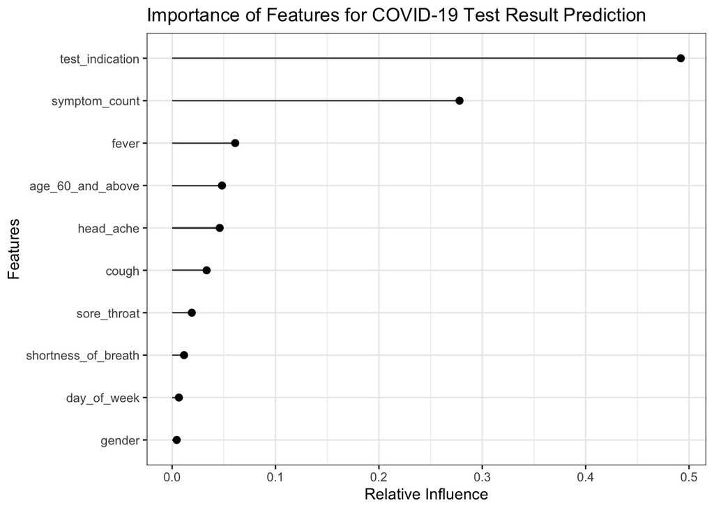

```r
# Extract feature importance
importance_matrix <- xgb.importance(model = xgb_tune$finalModel)

# Convert to tibble for easy manipulation
covid_features <- as_tibble(importance_matrix)

# Plot feature importance
covid_features %>%
  ggplot(aes(y = reorder(Feature, Gain), x = Gain)) +
  geom_col(width = 0.04) +
  geom_point(size = 2) +
  theme_bw() +
  labs(x = "Relative Influence", y = "Features", title = "Importance of Features for COVID-19 Test Result Prediction")
```

An interesting comparison with the final logistic regression model:

```r
summary(log_model_st)
```

```
##
## Call:
## glm(formula = corona_result ~ ., family = binomial, data = covid_train_6_4)
##
## Coefficients: (1 not defined because of singularities)
##                                       Estimate Std. Error z value Pr(>|z|)
## (Intercept)                           -1.58863    0.08206 -19.359  < 2e-16 ***
## coughYes                               0.62724    0.05305  11.824  < 2e-16 ***
## feverYes                               1.54379    0.05662  27.267  < 2e-16 ***
## sore_throatYes                         3.72608    0.31416  11.861  < 2e-16 ***
## shortness_of_breathYes                 3.40593    0.30335  11.228  < 2e-16 ***
## head_acheYes                           4.38178    0.34065  12.863  < 2e-16 ***
## age_60_and_aboveNone                  -0.71577    0.04545 -15.747  < 2e-16 ***
## age_60_and_aboveYes                    0.41234    0.05900   6.989 2.77e-12 ***
## gendermale                             0.30254    0.04031   7.505 6.13e-14 ***
## test_indicationContact with confirmed  4.41795    0.10110  43.697  < 2e-16 ***
## test_indicationOther                  -0.09517    0.06263  -1.519   0.1287
## day_of_weekTuesday                     0.03911    0.07021   0.557   0.5775
## day_of_weekWednesday                  -0.12474    0.07306  -1.707   0.0877 .
## day_of_weekThursday                    0.01805    0.07113   0.254   0.7997
## day_of_weekFriday                     -0.05197    0.07383  -0.704   0.4815
## day_of_weekSaturday                   -0.02512    0.07946  -0.316   0.7519
## day_of_weekSunday                     -0.09116    0.07332  -1.243   0.2138
## symptom_count                               NA         NA      NA       NA
## ---
## Signif. codes:  0 '***' 0.001 '**' 0.01 '*' 0.05 '.' 0.1 ' ' 1
##
## (Dispersion parameter for binomial family taken to be 1)
##
##     Null deviance: 31089  on 22927  degrees of freedom
## Residual deviance: 16421  on 22911  degrees of freedom
## AIC: 16455
##
## Number of Fisher Scoring iterations: 8
```

Interestingly, logistic regression puts slightly different importance on some variables (individual symptoms) while XGBoost model relies heavily on the reason for testing and symptom count.

### Observations

# Conclusions

Overall, the predictive model can be considered a moderate success. While the performance did not reach satisfactory numbers, the analysis proved significant improvements over the baseline models. The conclusions are:

- Exploratory analysis showed number of symptoms and reason for testing being the best predictors, which proved correct in the exploratory part.
- Individual symptoms cannot be used to predict COVID test results. By adding demographic variables and changing the ratio of positive results, model performance in sensitivity can be improved up to 76% with a boosting algorithm. Hyperparameter tuning and cross validation does not yield improvements.
- There is a certain threshold as many infected individuals show no signs of sickness and prediction thus relies only on the reason for testing which can be limited.
- Further improvements can be explored by testing other splits of negative/positive results, engineering polynomial and high-dimensional features (such as all possible interaction combinatons of symptoms), which were outside of the scope of this analysis.

# References

Gareth, J., Witten, D., Hastie, T., Tibshirani, R. 2021. *An Introduction to Statistical Learning with Applications in R*. New York, NY:Spinger. pp.497-532

Hastie, T., Tibshirani, R., Friedman, J. 2009. *The Elements of Statistical Learning*. 2nd ed. New York, NY:Spinger.

Kashnitsky, Y., 2023a. *Classification, Decision Trees and k Nearest Neighbors* [Online]. Available from: https://mlcourse.ai/book/topic03/topic03_decision_trees_kNN.html [Accessed on December 14, 2024]

Kashnitsky, Y., 2023b. *Exploratory Data Analysis with Pandas* [Online]. Available from: https://mlcourse.ai/book/topic01/topic01_pandas_data_analysis.html [Accessed on December 13, 2024]

Kravchenko, A. 2023. *Feature Engineering and Feature Selection* [Online]. Available from: https://mlcourse.ai/book/topic06/topic6_feature_engineering_feature_selection.html [Accessed on December 14, 2024]

Lantz, B. 2015. *Machine Learning with R - Discover How to Build Machine Learning Algorithms, Prepare Data, and Dig Deep into Data Prediction Techniques with R*. 2nd edn. Birmingham: Packt Publishing.

Natekin, A. 2023. *Gradient Boosting* [Online]. Available from: https://mlcourse.ai/book/topic10/topic10_gradient_boosting.html [Accessed on December 14, 2024]

Polusmak, E., 2023. *Visual Data Analysis.*[Online] Available from: https://mlcourse.ai/book/topic02/topic02_visual_data_analysis.html [Accessed on October 13, 2024]